# student_notebook_light_conditions_python3_20251015

Exp2021-10-3/2

### Sugar production under short- and long-day light regime

**Motivation:** Clock mutants can show different metabolic performance under different light conditions

Authors: Ines Boehm, Tomasz Zieliński

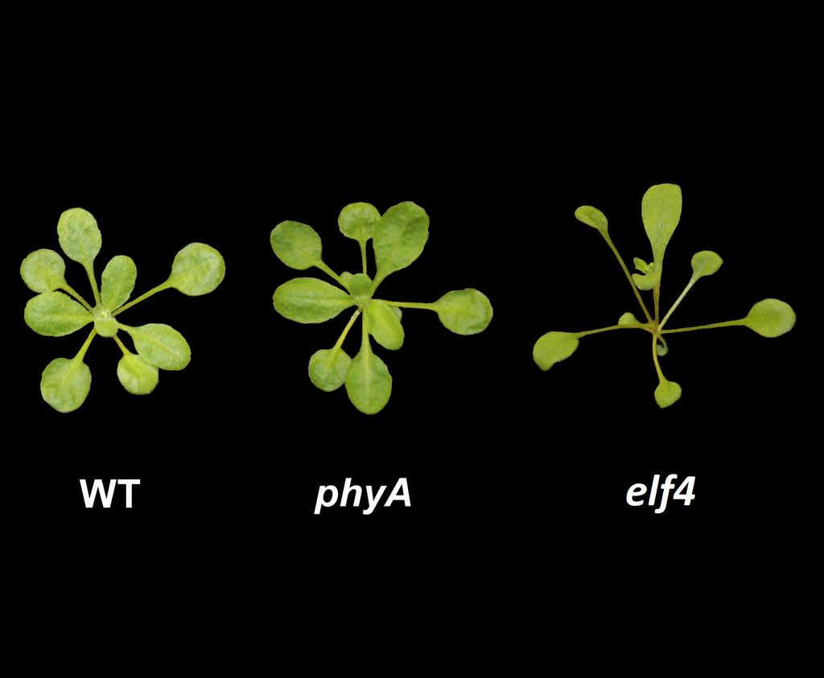

Phenotypes of 3-week-old plants

**Experiment details:**

Growth protocol: https://bio-protocol.org/bio101/e126 Measurement protocols: Chlorophyll and starch assay (https://doi.org/10.1038/nprot.2009.12), Quantification of starch (https://doi.org/10.1038/nprot.2006.232)

- Metabolites reported per g of fresh weight of 6-week-old plant leaf rosettes
- Study date range: 2019-12-05 to 2020-01-05
- SD = short days 6h light
- LD = long days 18h light

**Tested lines:**

- WT
- PhyA-211
- elf4

This file is part of the Jupyter Notebook lesson within the FAIR in (biological) practice DataCarpentry course run by Ed-DaSH.

```python
#################################################
#                                               #
# Hashtags are not run as code and are used for #
# annotation of code in Python.                 #
#################################################
```

```python
### Import packages

# Data processing
import pandas as pd

# Plotting
import matplotlib.pyplot as plt
from plotnine import ggplot, aes, geom_boxplot, labs, scale_fill_manual, theme_bw
from plotnine.data import mtcars

# Statistical analysis
import statsmodels.api as sm
from statsmodels.formula.api import ols

from statsmodels.stats.multicomp import pairwise_tukeyhsd
```

## Import data

```python
### Load dataset

df = pd.read_csv("light_results.txt", sep="\t", decimal=".")
```

```python
### Print dataframe
df
```

|  | genotype | light_condition | biomass | starch | sucrose | chlorophyll |
| --- | --- | --- | --- | --- | --- | --- |
| 0 | WT | SD | 0.091233 | 4.117647 | 1.422275 | 1.850892 |
| 1 | WT | SD | 0.150398 | 3.052525 | 0.925752 | 1.368901 |
| 2 | WT | SD | 0.039106 | 3.509443 | 0.720616 | 0.713928 |
| 3 | WT | SD | 0.117222 | 3.743908 | 0.488752 | 0.742666 |
| 4 | WT | SD | 0.145970 | 5.843862 | -0.326624 | 0.699232 |
| 5 | WT | SD | 0.135058 | 3.348050 | 1.265669 | 1.234547 |
| 6 | WT | SD | 0.125284 | 4.235387 | -0.030320 | 0.769122 |
| 7 | WT | SD | 0.087965 | 4.077961 | 1.069974 | 1.843958 |
| 8 | WT | SD | 0.077515 | 3.038143 | 1.654552 | NaN |
| 9 | WT | SD | 0.068794 | 3.928692 | -0.021947 | 0.856485 |
| 10 | WT | LD | 0.181581 | 4.784619 | 0.681002 | NaN |
| 11 | WT | LD | 0.118525 | 5.065293 | 1.378956 | 1.902594 |
| 12 | WT | LD | 0.112195 | 4.965933 | 0.895105 | 2.028375 |
| 13 | WT | LD | 0.247231 | 7.128452 | 0.740346 | 1.731391 |
| 14 | WT | LD | 0.137494 | 4.258664 | 0.929116 | 1.606760 |
| 15 | WT | LD | 0.158947 | 3.904004 | 0.940847 | NaN |
| 16 | WT | LD | 0.169097 | 5.037788 | 1.332976 | 2.180213 |
| 17 | WT | LD | 0.135487 | 5.310481 | 1.025421 | 1.624619 |
| 18 | WT | LD | 0.165506 | 5.436523 | 1.226216 | 1.816650 |
| 19 | WT | LD | 0.161069 | 4.541635 | 0.850212 | 1.644356 |
| 20 | PhyA-211 | SD | 0.186722 | 2.864353 | 1.426464 | 1.305293 |
| 21 | PhyA-211 | SD | 0.160794 | 4.564050 | 0.704929 | 1.792083 |
| 22 | PhyA-211 | SD | 0.162023 | 2.947991 | 1.895126 | 0.734604 |
| 23 | PhyA-211 | SD | 0.153320 | 3.542218 | 1.878133 | 4.168956 |
| 24 | PhyA-211 | SD | 0.133325 | 3.749921 | 1.821581 | 3.207962 |
| 25 | PhyA-211 | SD | 0.203607 | 1.626613 | 1.688640 | 0.876891 |
| 26 | PhyA-211 | SD | 0.164936 | 6.675574 | 1.553918 | 1.597115 |
| 27 | PhyA-211 | SD | 0.091001 | 5.306746 | 0.938088 | 1.533345 |
| 28 | PhyA-211 | SD | 0.171041 | 2.723726 | 0.694037 | 2.779965 |
| 29 | PhyA-211 | SD | 0.135816 | 7.507630 | 0.619529 | NaN |
| 30 | PhyA-211 | LD | 0.268982 | 6.508969 | 2.002882 | 3.496752 |
| 31 | PhyA-211 | LD | 0.224884 | 4.690831 | 2.192640 | 3.274198 |
| 32 | PhyA-211 | LD | 0.233340 | 8.005739 | 1.814670 | 3.119366 |
| 33 | PhyA-211 | LD | 0.199071 | 6.290799 | 2.322188 | 2.686047 |
| 34 | PhyA-211 | LD | 0.196410 | 6.311991 | 1.889757 | 3.680326 |
| 35 | PhyA-211 | LD | 0.265176 | 8.025571 | 2.165891 | 2.699870 |
| 36 | PhyA-211 | LD | 0.272410 | 6.715227 | 2.548420 | 4.093666 |
| 37 | PhyA-211 | LD | 0.252650 | 5.779282 | 2.217591 | 3.766305 |
| 38 | PhyA-211 | LD | 0.296113 | 7.181303 | 1.837034 | 2.882150 |
| 39 | PhyA-211 | LD | 0.352504 | 6.861109 | 2.574404 | 2.486790 |
| 40 | elf4-101 | SD | 0.083577 | 2.713013 | 1.377647 | 0.705689 |
| 41 | elf4-101 | SD | 0.087311 | 3.308993 | 0.354840 | 0.848901 |
| 42 | elf4-101 | SD | 0.116974 | 3.554924 | 0.507269 | NaN |
| 43 | elf4-101 | SD | 0.064518 | 3.353794 | 0.030736 | 0.531348 |
| 44 | elf4-101 | SD | 0.050225 | 2.818171 | 0.112806 | 1.010474 |
| 45 | elf4-101 | SD | 0.130271 | 3.029875 | -0.258508 | 2.051181 |
| 46 | elf4-101 | SD | 0.066765 | 2.647702 | 0.308537 | 1.049513 |
| 47 | elf4-101 | SD | 0.058308 | 2.641391 | 0.609491 | 0.420080 |
| 48 | elf4-101 | SD | 0.042912 | 3.442325 | 0.562152 | 0.767615 |
| 49 | elf4-101 | SD | 0.041459 | 2.492204 | 0.009232 | 1.342730 |
| 50 | elf4-101 | LD | 0.093944 | 4.422507 | 0.299757 | NaN |
| 51 | elf4-101 | LD | 0.095506 | 4.481264 | 1.020949 | 1.816254 |
| 52 | elf4-101 | LD | 0.122358 | 4.342155 | 0.915808 | 1.843579 |
| 53 | elf4-101 | LD | 0.185010 | 3.302363 | 0.720305 | 1.326760 |
| 54 | elf4-101 | LD | 0.234654 | 4.424822 | 0.835443 | 2.100745 |
| 55 | elf4-101 | LD | 0.197379 | 3.776721 | 0.840212 | 1.520010 |
| 56 | elf4-101 | LD | 0.113342 | 4.087401 | 0.866306 | 2.060056 |
| 57 | elf4-101 | LD | 0.032174 | 4.037276 | 1.292254 | 1.094729 |
| 58 | elf4-101 | LD | 0.100561 | 4.214083 | 0.734285 | 1.506295 |
| 59 | elf4-101 | LD | 0.124460 | 4.012337 | 0.850420 | NaN |

**Table 1:** Genotypes (WT = wild type, PhyA-211, elf4-101) are listed with respective measurements for biomass (g), starch (mg/g FW), sucrose (mg/g FW) and chlorophyll (mg/g FW) under short- and long-day light regimes.

## Visualise data

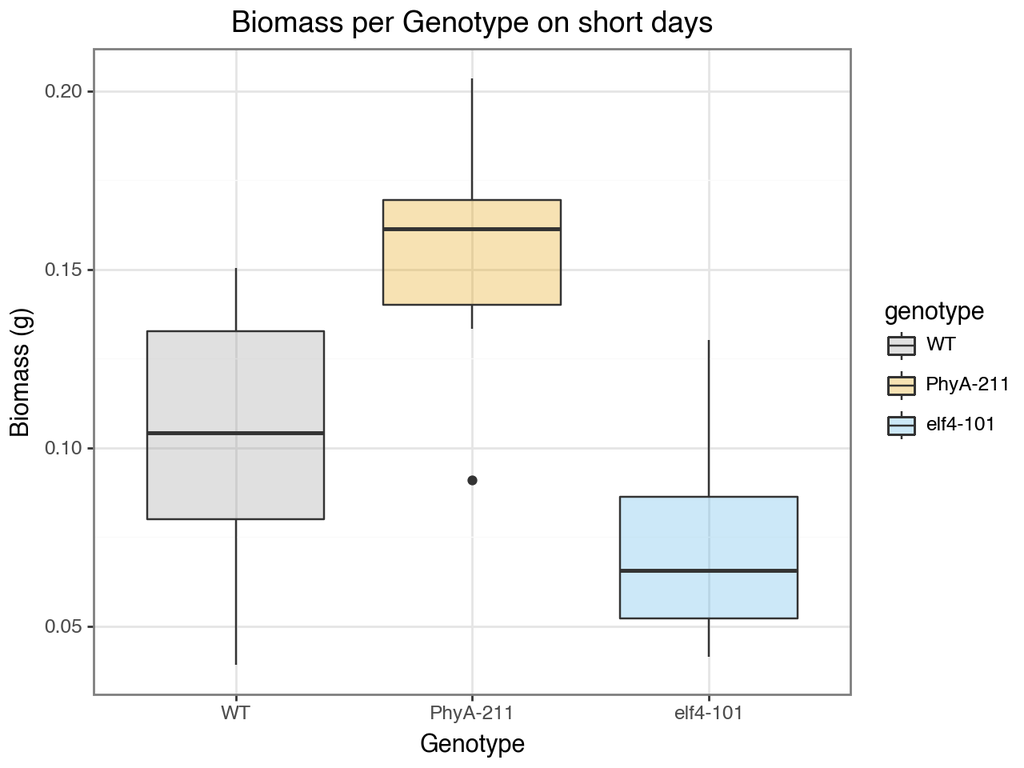

```python
# Create ggplot subset by light_condition

# first change order of factors of the genotype table
# ggplot's standard setting is set to alphabetical order so your plot would read elf, phyA, WT
# If you rerun the code with a hashtag in front of the line you can look
# at the difference in the plot!
df['genotype'] = pd.Categorical(df['genotype'], categories=['WT', 'PhyA-211', 'elf4-101'], ordered=True)

# change the size of the plot so it fits the screen before plotting
plt.rcParams['figure.figsize'] = (5, 4)

# plot your graph
(ggplot(df[df['light_condition'] == 'SD'], aes(x='genotype', y='biomass', fill='genotype')) +
 geom_boxplot(alpha=0.3) +
 labs(title="Biomass per Genotype on short days",
      x="Genotype",  # Title of x-axis
      y="Biomass (g)") +  # Title of y-axis
 scale_fill_manual(values=["#999999", "#E69F00", "#56B4E9"]) + theme_bw())  # change color of groups
```

**Figure 1:** Biomass (g) per genotype on short days shows a much larger biomass production in PhyA-211 in comparison to wild-type. Elf4-101 has a marginally smaller biomass production than wild-type during short days.

To quantify this we have explored our data and run a ONE-way ANOVA plus Tukey multiple pairwise test.

## Statistical testing

```python
# Run a one-way ANOVA - compute the variance of biomass between genotypes
# ONLY from data within short-day light condition

res = ols('biomass ~ genotype', data=df[df['light_condition'] == 'SD']).fit()
aov_table = sm.stats.anova_lm(res)
print(aov_table)
```

```
            df    sum_sq   mean_sq          F    PR(>F)
genotype   2.0  0.034507  0.017253  16.025936  0.000026
Residual  27.0  0.029068  0.001077        NaN       NaN
```

```python
print(res.summary())
```

```
                            OLS Regression Results
==============================================================================
Dep. Variable:                biomass   R-squared:                       0.543
Model:                            OLS   Adj. R-squared:                  0.509
Method:                 Least Squares   F-statistic:                     16.03
Date:                Wed, 15 Oct 2025   Prob (F-statistic):           2.58e-05
Time:                        10:12:35   Log-Likelihood:                 61.522
No. Observations:                  30   AIC:                            -117.0
Df Residuals:                      27   BIC:                            -112.8
Df Model:                           2
Covariance Type:            nonrobust
========================================================================================
                           coef    std err          t      P>|t|      [0.025      0.975]
----------------------------------------------------------------------------------------
Intercept                0.1039      0.010     10.009      0.000       0.083       0.125
genotype[T.PhyA-211]     0.0524      0.015      3.571      0.001       0.022       0.083
genotype[T.elf4-101]    -0.0296      0.015     -2.019      0.054      -0.060       0.000
==============================================================================
Omnibus:                        0.263   Durbin-Watson:                   2.239
Prob(Omnibus):                  0.877   Jarque-Bera (JB):                0.452
Skew:                          -0.120   Prob(JB):                        0.798
Kurtosis:                       2.449   Cond. No.                         3.73
==============================================================================

Notes:
[1] Standard Errors assume that the covariance matrix of the errors is correctly specified.
```

**NOTE:** The output includes the columns F value and Pr(>F) corresponding to the p-value of the test.

```python
# Perform Tukey's HSD test
tukey_results = pairwise_tukeyhsd(endog=df['biomass'], groups=df['genotype'], alpha=0.05)
print(tukey_results)
```

```
  Multiple Comparison of Means - Tukey HSD, FWER=0.05
========================================================
 group1   group2  meandiff p-adj   lower   upper  reject
--------------------------------------------------------
PhyA-211       WT  -0.0749 0.0002  -0.117 -0.0328   True
PhyA-211 elf4-101  -0.1041    0.0 -0.1462  -0.062   True
      WT elf4-101  -0.0292 0.2257 -0.0713  0.0129  False
--------------------------------------------------------
```

**NOTE**

- diff: difference between means of the two groups
- lwr, upr: the lower and the upper end point of the confidence interval at 95% (default)
- p adj: p-value after adjustment for the multiple comparisons.

**RESULT**